# Final Project: RNA-Seq Analysis

**Sandy Kim (404830610)**

In this final project, I aim to explore various methods of RNA-seq data analysis in order to (1) try out different methods of analysis and (2) gain familiarity with R.

I will be following two different tutorials, where code is provided, but thorough analysis of resulting graphs is not: https://www.bioconductor.org/help/course-materials/2015/LearnBioconductorFeb2015/B02.1.1_RNASeqLab.html and https://bioc.ism.ac.jp/packages/3.8/workflows/vignettes/rnaseqGene/inst/doc/rnaseqGene.html.

First, we need to load some packages. One of which include “airway”, which is a dataset from an RNA-Seq experiment on four human airway smooth muscle cell lines treated with dexamethasone, a synthetic glucocorticoid steroid with anti-inflammatory effects. Glucocorticoids are used, for example, in asthma patients to prevent or reduce inflammation of the airways. In the experiment, four primary human airway smooth muscle cell lines were treated with 1 micromolar dexamethasone for 18 hours. For each of the four cell lines, we have a treated and an untreated sample. It also contains a small subset of the raw data, namely eight BAM file each with a subset of the reads.

The reference for the experiment is: Himes BE, Jiang X, Wagner P, Hu R, Wang Q, Klanderman B, Whitaker RM, Duan Q, Lasky-Su J, Nikolos C, Jester W, Johnson M, Panettieri R Jr, Tantisira KG, Weiss ST, Lu Q. ‘RNA-Seq Transcriptome Profiling Identifies CRISPLD2 as a Glucocorticoid Responsive Gene that Modulates Cytokine Function in Airway Smooth Muscle Cells.’ PLoS One. 2014 Jun 13;9(6):e99625. PMID: 24926665.

```r
library(htmltools)
library("DESeq2")
library(ggplot2)
library("airway")
library("gplots")
library("RColorBrewer")
library("genefilter")
library("pheatmap")
library("PoiClaClu")
```

Then we want to load in our data.

```r
data("airway")
se <- airway
```

We need to make sure we have all the necessary information about the samples prior to performing analysis.

```r
colData(se)
```

```
DataFrame with 8 rows and 9 columns
           SampleName     cell      dex    albut        Run avgLength Experiment    Sample
             <factor> <factor> <factor> <factor>   <factor> <integer>   <factor>  <factor>
SRR1039508 GSM1275862  N61311     untrt    untrt SRR1039508       126  SRX384345 SRS508568
SRR1039509 GSM1275863  N61311     trt      untrt SRR1039509       126  SRX384346 SRS508567
SRR1039512 GSM1275866  N052611    untrt    untrt SRR1039512       126  SRX384349 SRS508571
SRR1039513 GSM1275867  N052611    trt      untrt SRR1039513        87  SRX384350 SRS508572
SRR1039516 GSM1275870  N080611    untrt    untrt SRR1039516       120  SRX384353 SRS508575
SRR1039517 GSM1275871  N080611    trt      untrt SRR1039517       126  SRX384354 SRS508576
SRR1039520 GSM1275874  N061011    untrt    untrt SRR1039520       101  SRX384357 SRS508579
SRR1039521 GSM1275875  N061011    trt      untrt SRR1039521        98  SRX384358 SRS508580
              BioSample
               <factor>
SRR1039508 SAMN02422669
SRR1039509 SAMN02422675
SRR1039512 SAMN02422678
SRR1039513 SAMN02422670
SRR1039516 SAMN02422682
SRR1039517 SAMN02422673
SRR1039520 SAMN02422683
SRR1039521 SAMN02422677
```

Here, we can see that this object contains an informative colData, because, well, it was already prepared for us in the package. Information includes sample / phenotypic information for the experiment at this stage.

Since we have our annotated dataset, we can move forward by constructing a DESeqDataSet object from it!

```r
dds <- DESeqDataSet(se, design = ~ cell + dex)
```

Let’s take a look at the count matrices, and the reads themselves.

```r
countdata <- assay(se)
coldata <- colData(se)
(ddsMat <- DESeqDataSetFromMatrix(countData = countdata,
                                 colData = coldata,
                                 design = ~ cell + dex))
```

```
class: DESeqDataSet
dim: 64102 8
metadata(1): version
assays(1): counts
rownames(64102): ENSG00000000003 ENSG00000000005 ... LRG_98 LRG_99
rowData names(0):
colnames(8): SRR1039508 SRR1039509 ... SRR1039520 SRR1039521
colData names(9): SampleName cell ... Sample BioSample
```

To survey the dataset, we will look at the standard deviation as mean increase.

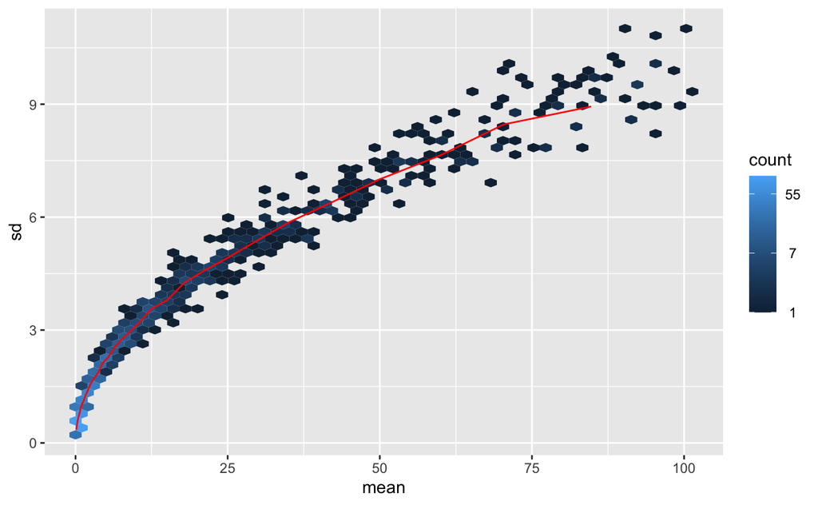

```r
lambda <- 10^seq(from = -1, to = 2, length = 1000)
cts <- matrix(rpois(1000*100, lambda), ncol = 100)
meanSdPlot(cts, ranks = FALSE)
```

This type of data is not good to perform analysis on! For instance, if you perform PCA on the data as it is (raw or normalized), the resulting plot typically depends mostly on the genes with highest counts because they show the largest absolute differences between samples.

So, we log-transform our counts.

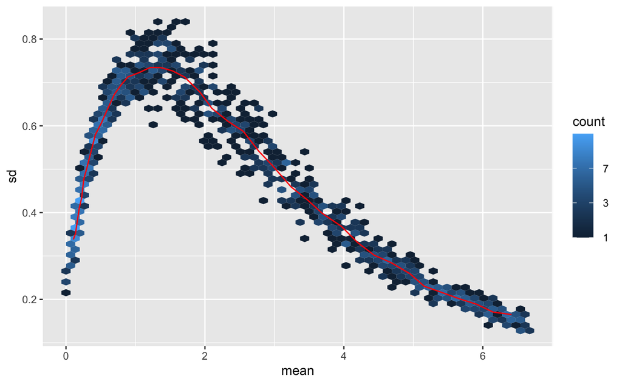

```r
log.cts.one <- log2(cts + 1)
meanSdPlot(log.cts.one, ranks = FALSE)
```

We can see from the graph above, standard deviation no longer increases with the mean! However, differences are amplified when values are close to 0. This is seen where the standard deviation grows very quickly when the mean close to zero, and overcomes a “hill” at around mean ofone. In this case, low count genes with low signal-to-noise ratio will overly contribute to PCA plots.

Luckily DESeq offers the regularized-logarithm transformation or rlog (Love, Huber, and Anders 2014), which can transform our data such that the data has same range of variance at different ranges of the mean values and the variance doesn’t depend on the mean. This allows for computing distances between samples, like in a PCA plot!

```r
rld <- rlog(dds)
head(assay(rld))
```

```
                SRR1039508 SRR1039509 SRR1039512 SRR1039513 SRR1039516 SRR1039517
ENSG00000000003   9.399155   9.142506   9.501691   9.320807   9.757189   9.512179
ENSG00000000005   0.000000   0.000000   0.000000   0.000000   0.000000   0.000000
ENSG00000000419   8.901297   9.113966   9.032566   9.063920   8.981935   9.108522
ENSG00000000457   7.949882   7.882372   7.834287   7.916451   7.773848   7.886645
ENSG00000000460   5.849509   5.882324   5.487269   5.770392   5.940321   5.664001
ENSG00000000938  -1.369632  -1.367411  -1.305192  -1.362554  -1.338570  -1.373842
                SRR1039520 SRR1039521
ENSG00000000003   9.617365   9.315321
ENSG00000000005   0.000000   0.000000
ENSG00000000419   8.894845   9.052299
ENSG00000000457   7.946396   7.908333
ENSG00000000460   6.107519   5.907764
ENSG00000000938  -1.367863  -1.368288
```

For genes with high counts, the rlog transformation differs not much from an ordinary log2 transformation. For genes with lower counts, however, the values are shrunken towards the genes’ averages across all samples.

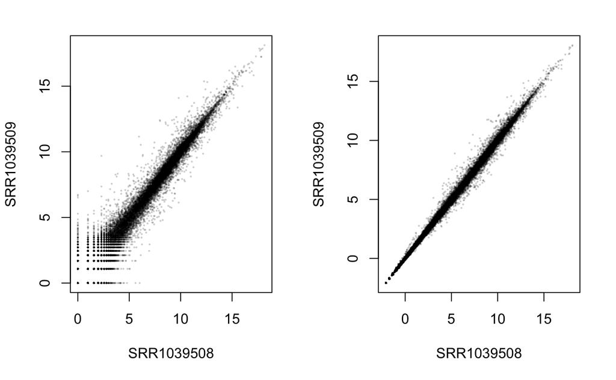

```r
par( mfrow = c( 1, 2 ) )
dds <- estimateSizeFactors(dds)
plot( log2( 1 + counts(dds, normalized=TRUE)[ , 1:2] ),
     col=rgb(0,0,0,.2), pch=16, cex=0.3 )
plot( assay(rld)[ , 1:2],
     col=rgb(0,0,0,.2), pch=16, cex=0.3 )
```

```r
poisd <- PoissonDistance(t(counts(dds)))
```

We can also visualize distances using a principal component analysis plot.

```r
(data <- plotPCA(rld, intgroup = c( "dex", "cell"), returnData=TRUE))
```

|  | PC1 | PC2 | group | dex | cell | name |
| --- | --- | --- | --- | --- | --- | --- |
| SRR1039508 | -14.326791 | -4.205271 | untrt:N61311 | untrt | N61311 | SRR1039508 |
| SRR1039509 | 6.752236 | -2.242264 | trt:N61311 | trt | N61311 | SRR1039509 |
| SRR1039512 | -8.128701 | -3.950350 | untrt:N052611 | untrt | N052611 | SRR1039512 |
| SRR1039513 | 14.500816 | -2.940329 | trt:N052611 | trt | N052611 | SRR1039513 |
| SRR1039516 | -11.887297 | 13.728272 | untrt:N080611 | untrt | N080611 | SRR1039516 |
| SRR1039517 | 8.371955 | 17.815856 | trt:N080611 | trt | N080611 | SRR1039517 |
| SRR1039520 | -9.962960 | -10.012013 | untrt:N061011 | untrt | N061011 | SRR1039520 |
| SRR1039521 | 14.680742 | -8.193902 | trt:N061011 | trt | N061011 | SRR1039521 |

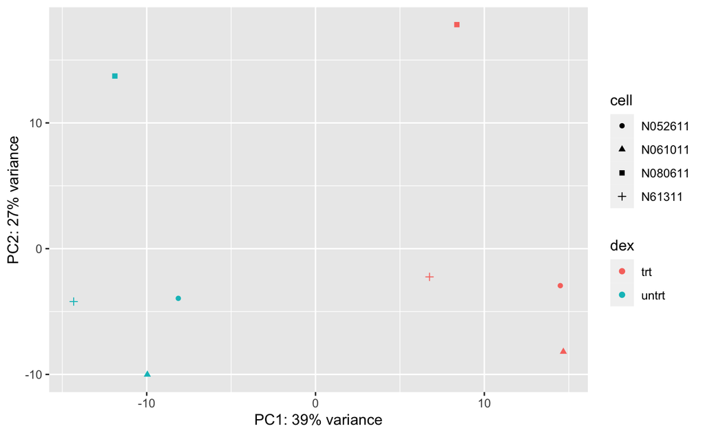

```r
percentVar <- round(100 * attr(data, "percentVar"))
qplot(PC1, PC2, color=dex, shape=cell, data=data) +
  xlab(paste0("PC1: ",percentVar[1],"% variance")) +
  ylab(paste0("PC2: ",percentVar[2],"% variance"))
```

From above, we can see that the untreated samples are closer to one another, and the treated samples are closer to one another, regardless of cell type. While the distances between different cell types are considerable, differences due to the treatment are stronger. This indicates that dexamethasone has a significant effect. It is important to note that cell types also do locate similarly relative to other cell types, although it is not as of a strong separation. But it’s also interesting to note that these two PCs only capture a little over 60% of the variance of the original dataset.

Let’s take a look at differential expression analysis to see what genes are causing these considerable distances.

```r
dds$dex <- relevel(dds$dex, "untrt")
dds <- DESeq(dds)
(res <- results(dds))
```

```
log2 fold change (MLE): dex trt vs untrt
Wald test p-value: dex trt vs untrt
DataFrame with 64102 rows and 6 columns
                 baseMean log2FoldChange     lfcSE      stat      pvalue       padj
                <numeric>      <numeric> <numeric> <numeric>   <numeric>  <numeric>
ENSG00000000003  708.6022     -0.3812539  0.100654 -3.787751 0.000152017 0.00128364
ENSG00000000005    0.0000             NA        NA        NA          NA         NA
ENSG00000000419  520.2979      0.2068127  0.112219  1.842944 0.065337210 0.19654584
ENSG00000000457  237.1630      0.0379206  0.143445  0.264357 0.791504963 0.91145800
ENSG00000000460   57.9326     -0.0881677  0.287142 -0.307053 0.758803336 0.89503445
...                   ...            ...       ...       ...         ...        ...
LRG_94                  0             NA        NA        NA          NA         NA
LRG_96                  0             NA        NA        NA          NA         NA
LRG_97                  0             NA        NA        NA          NA         NA
LRG_98                  0             NA        NA        NA          NA         NA
LRG_99                  0             NA        NA        NA          NA         NA
```

```r
mcols(res, use.names=TRUE)
```

```
DataFrame with 6 rows and 2 columns
                       type                               description
                <character>                               <character>
baseMean       intermediate mean of normalized counts for all samples
log2FoldChange      results  log2 fold change (MLE): dex trt vs untrt
lfcSE               results          standard error: dex trt vs untrt
stat                results          Wald statistic: dex trt vs untrt
pvalue              results       Wald test p-value: dex trt vs untrt
padj                results                      BH adjusted p-values
```

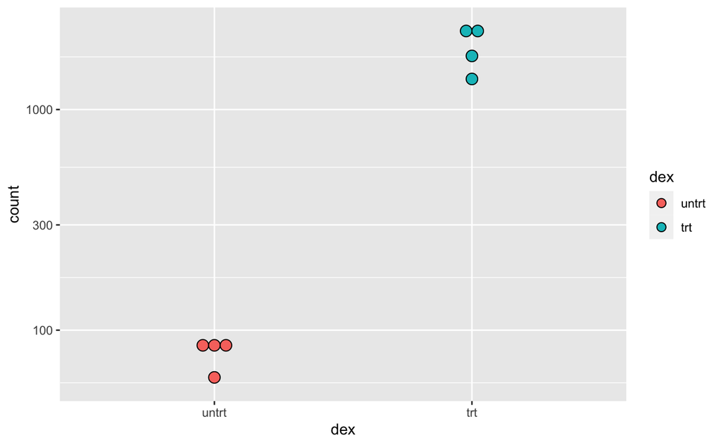

```r
topGene <- rownames(res)[which.min(res$padj)]
data <- plotCounts(dds, gene=topGene, intgroup=c("dex","cell"), returnData=TRUE)
ggplot(data, aes(x=dex, y=count, fill=dex)) +
  scale_y_log10() +
  geom_dotplot(binaxis="y", stackdir="center")
```

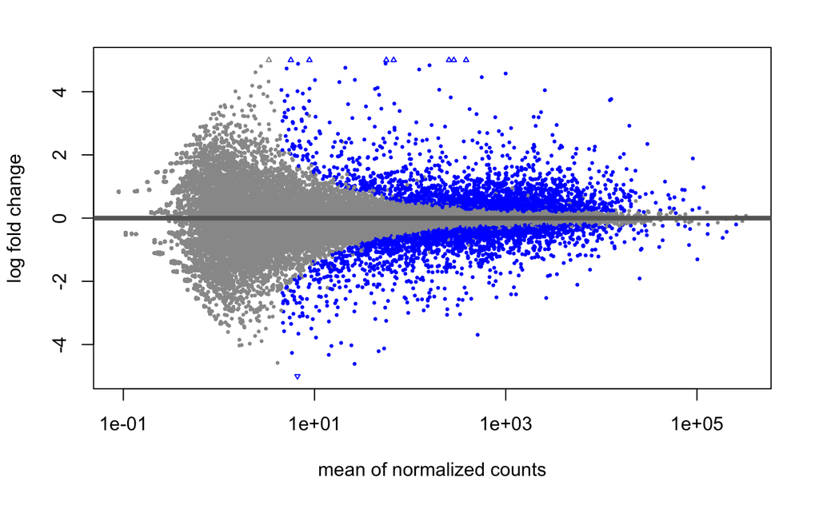

```r
plotMA(res, ylim=c(-5,5))
```

In addition, we can graph histogram of the p values, for genes with mean normalized count larger than 1.

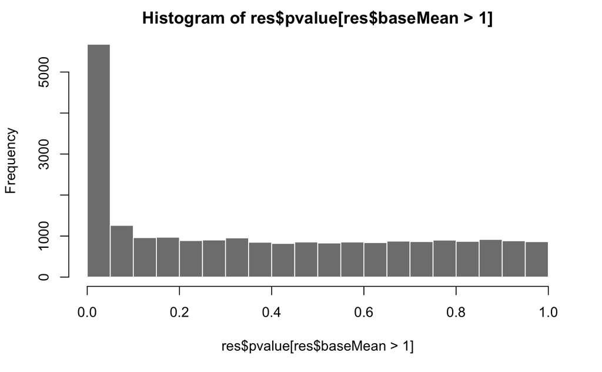

```r
hist(res$pvalue[res$baseMean > 1], breaks = 0:20/20,
     col = "grey50", border = "white")
```

As you can see from the histogram above, there are quite a number of genes that fall in p <= 0.05.

We can also cluster genes. It’s of great interest to only cluster genes that are highly variable as these genes are the ones that actually carry a signal. Here we look at the top 20. Instead of looking at absolute expression strength, we look at the amount by which each gene deviates in a specific sample from the gene’s average across all samples.

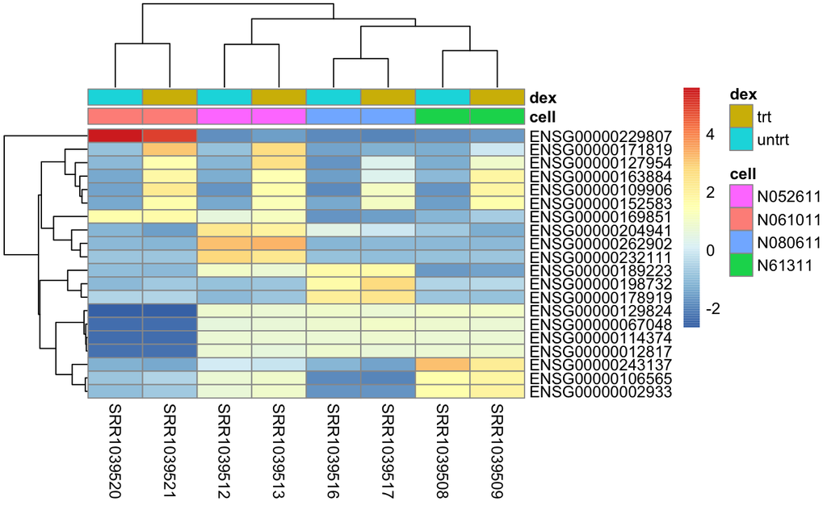

```r
topVarGenes <- head(order(rowVars(assay(rld)), decreasing = TRUE), 20)
mat  <- assay(rld)[ topVarGenes, ]
mat  <- mat - rowMeans(mat)
anno <- as.data.frame(colData(rld)[, c("cell","dex")])
pheatmap(mat, annotation_col = anno)
```

As seen in the heatmap above, there are bars that indicate treatment conditions and cell type conditions. It’s interesting to note that the first horizontal bar, you can see that the N061011 cell type is seperated from all other cell types in the fact that gene expression is higher than average compared to the rest of the cell types. In the 8th horizontal bar onwards, gene expression is lower than average compared to the rest of the cell types. In addition, dex-untreated samples tend to have lower expression than average (blue squares), than treated samples.

Cool. Well, that’s all I have. Thanks Derek and Professor Lee for a great quarter! : )